# Characteristics of Successful Protests

Data Cleaning

Text Mining

Author

Angel Feliz

Published

December 25, 2022

# Introduction

Protests are an important part of society change. In this time we are going to explore data from **The Mass Mobilization Project** which contains information about protests against governments, and contains a variety of variables such as location, dates and number of participants. The data is available in the [Mass Protest Data](https://github.com/datacamp/careerhub-data/tree/master/Mass%20Protest%20Data) Data Camp Github folder.

The goal of this project is to define what characteristics share successful protests worldwide. The first step to achieve that it is to define what do I mean with **successful**. As most the protests demand state actions *I consider that a **protest is successful** when there is a reconciliation between the two parts*.

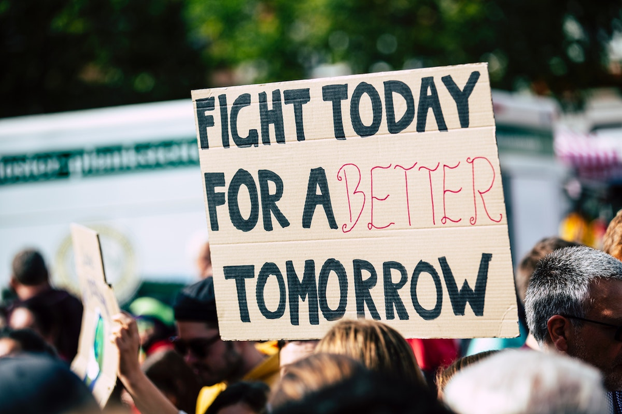

To make that possible we will apply the next skills during the process:

- **Functional programming** with *R*
- **Data manipulation** with *data.table*, *lubridate* and *stringr*
- **Bootstraping** with *infer*
- **Text mining** with *tidytext*
- **Data visualization** with *ggplot2*, *scales*, *forcats* and *patchwork*
- **Network visualization** with *igraph* and *ggraph*
- **Automated reporting** with *quarto*, *flextable*, *html* and *css*

The [source code](https://github.com/AngelFelizR/myblog/tree/main/projs/mass-protest-data) of this project is available on Github.

# 1 Enveroment set-up

Before starting to find insights from data it’s needed to load in R the functions and the data that we will use during the process.

## 1.1 Libraries importantion

Libraries are very useful, but they can change over time making that the code used today might not work tomorrow. So, the first step before loading the libraries is to save a file (*renv.lock*) with all R package dependencies and the next code line we validate if we are using the same version of each package.

```r
if (!requireNamespace("renv", quietly = TRUE)) install.packages("renv")
renv::restore()
```

```
* The library is already synchronized with the lockfile.
```

Now we can load the libraries and functions that we are going to use in the project.

```r
library(data.table)
library(lubridate)
library(stringr)

library(infer)

library(flextable)

library(ggplot2)
library(scales)
library(forcats)
library(igraph)
library(ggraph)

library(tidytext)

glimpse <- pillar::glimpse
codelist_panel <- countrycode::codelist_panel
correlation <- correlation::correlation
here <- here::here
```

## 1.2 Custom functions

Open-source packages are very powerful as they provide general purpose functions, but it’s also useful to have some custom project functions to perform repetitive task and improve code readability. During this project, we will use the following functions according to their purpose:

### 1.2.1 Styling

- **custom_theme:** Defines the style of all ggplots across the project.

```r
CustomTheme <-
theme_light()+
  theme(axis.text = element_text(size = 15),
        axis.title = element_text(size = 16, face = "bold"),
        strip.text = element_text(size = 16, face = "bold"),
        plot.title = element_text(size = 25, face = "bold",
                                  hjust = 0.5, margin = margin(b = 15)),

        legend.title = element_text(size = 15, face = "bold"),
        legend.text = element_text(size = 14))

theme_set(CustomTheme)
rm(CustomTheme)
```

- **style_table:** Takes a `data.frame` and renders it as html table with a custom style.

```r
style_table <- function(DF){

  flextable(DF) |>
    theme_vanilla() |>
    autofit()

}
```

### 1.2.2 Data cleaning

- **keep_lower_letters:** Lower the case all words in a vector and remove any character that isn’t a word.

```r
keep_lower_letters <- function(text){

  tolower(text) |>
    gsub(pattern = "[^A-Za-z ']", replacement = " ") |>
    gsub(pattern = "\\s+" , replacement = " ") |>
    trimws()

}
```

### 1.2.3 Data transformation

- **find_string_approximation:** This function merges two data.tables to generate all possible combinations between them and select for each id the match that minimize the string distance between words of both tables. This function was inspired by the `reclin2` package as both follow simular steps.

```r
find_string_approximation <- function(DT1,
                                      DT2,
                                      id.var,
                                      merge.by,
                                      match.vars,
                                      min.tolerance = 0.7,
                                      stringdist.method = "lcs"){

  merge(DT1, DT2, by = merge.by, allow.cartesian = TRUE
  )[, weight := 1 - stringdist::stringdist(get(match.vars[1]),get(match.vars[2]),
                                           method = stringdist.method) /
                    (nchar(get(match.vars[1]))+nchar(get(match.vars[2])))
  ][weight >= min.tolerance
  ][order(-weight),
    unique(.SD, by = id.var)]

}
```

### 1.2.4 Stadistics

- **get_percentile_ci**

```r
get_percentile_ci <- function(DF, variable, conf_level = 0.95, na.rm = TRUE){

  percentile1 <- (1-conf_level)/2
  percentile2 <- percentile1 + conf_level

  data.table(lower_ci = quantile(DF[[variable]], probs = percentile1, na.rm = na.rm, names =FALSE),
             point_estimate = median(DF[[variable]], na.rm = na.rm),
             upper_ci = quantile(DF[[variable]], probs = percentile2, na.rm = na.rm, names =FALSE))
}
```

### 1.2.5 Plotting

- **plot_word_found_distribution:** Creates a plot to show how the found words are distributed acording the number of words that have the `word.count.var`.

```r
plot_word_found_distribution <- function(DT,
                                         word.count.var,
                                         prostest.id.found,
                                         success.label,
                                         no.found.label,
                                         label.colors,
                                         title = "Number of words distribution",
                                         subtitle = "",
                                         x.lab = "Number of words",
                                         y.lab = ""){

  DT[!is.na(get(word.count.var)),
     .(id,
       word_count =  str_count(get(word.count.var)," ")+1,
       success = fifelse(id %in% prostest.id.found,
                         success.label,
                         no.found.label) |>
                 factor(levels = names(label.colors)[c(2,1)] ))] |>
    ggplot(aes(x = word_count,y = success, color = success))+
    geom_jitter(alpha = 0.20, size = 2, height = 0.40, width = 0.15)+
    scale_x_continuous(breaks = breaks_width(1,1))+
    scale_color_manual(values = label.colors)+
    labs(title = title, subtitle = subtitle, x = x.lab, y = y.lab)+
    theme(plot.subtitle = element_text(size = 18, margin = margin(b = 15)),
          panel.grid.major.y = element_blank(),
          legend.position = "none")

}
```

## 1.3 Data importation

In this section we will take the data available and load it into R as `data.table` objects.

### 1.3.1 Main data

**ProtestRaw** will be the main reference to use during the analysis. Any other imported data during this project will be used to extend or clean the information given in this data.

```r
ProtestRaw <-
  fread(here("Raw-data/protest_data.csv"),
        na.strings = "", integer64 = "double")

glimpse(ProtestRaw)
```

```
Rows: 17,145
Columns: 31
$ id                    <dbl> 201990001, 201990002, 201990003, 201990004, 2019…
$ country               <chr> "Canada", "Canada", "Canada", "Canada", "Canada"…
$ ccode                 <int> 20, 20, 20, 20, 20, 20, 20, 20, 20, 20, 20, 20, …
$ year                  <int> 1990, 1990, 1990, 1990, 1990, 1990, 1991, 1991, …
$ region                <chr> "North America", "North America", "North America…
$ protest               <int> 1, 1, 1, 1, 1, 1, 1, 1, 1, 1, 1, 1, 1, 1, 1, 1, …
$ protestnumber         <int> 1, 2, 3, 4, 5, 6, 1, 2, 1, 1, 2, 1, 2, 1, 2, 1, …
$ startday              <int> 15, 25, 1, 12, 14, 19, 10, 28, 4, 16, 1, 1, 18, …
$ startmonth            <int> 1, 6, 7, 7, 8, 9, 9, 9, 5, 5, 7, 9, 11, 2, 9, 10…
$ startyear             <int> 1990, 1990, 1990, 1990, 1990, 1990, 1991, 1991, …
$ endday                <int> 15, 25, 1, 6, 15, 19, 17, 2, 5, 16, 31, 1, 18, 2…
$ endmonth              <int> 1, 6, 7, 9, 8, 9, 9, 10, 5, 5, 8, 9, 11, 2, 9, 1…
$ endyear               <int> 1990, 1990, 1990, 1990, 1990, 1990, 1991, 1991, …
```

[output cut: 18 more lines]

### 1.3.2 Complementary data

Let’s import complementary data to make sense, clean and expand the information provided in `ProtestRaw`.

- **WorldCities:** It has information about 239 countries and their cities. It will be used to clean the `location` field in the main data. The data can be found in [Simple Maps](https://simplemaps.com/data/world-cities) as a free database.

```r
WorldCities <-
  fread(here("Raw-data/worldcities.csv"), na.strings = "", sep=",",
        select = c("country","city_ascii","capital","population")
  )[order(country,-population)

  # Applying some manual modifications to assure that ProtestRaw and WorlCites
  # use the same name for the same country
  ][,`:=`(country = fcase(country == "Hong Kong","China",
                          country == "The Gambia","Gambia",
                          country == "United Arab Emirates","United Arab Emirate",
                          country == "Cabo Verde", "Cape Verde",
                          country == "Bosnia And Herzegovina","Bosnia",
                          country == "Slovakia", "Slovak Republic",
                          country == "Czechia","Czech Republic",
                          rep(TRUE,.N), country) |>
                   keep_lower_letters(),
          city_ascii = keep_lower_letters(city_ascii))

  # Identifying the capital of each country in each raw
  ][!capital %like% "\\w",
    capital := NA_character_
  ][country == "taiwan" & city_ascii == "taipei",
    capital := "primary"]

glimpse(WorldCities)
```

```
Rows: 42,905
Columns: 4
$ country    <chr> "afghanistan", "afghanistan", "afghanistan", "afghanistan",…
$ city_ascii <chr> "kabul", "kandahar", "herat", "mazar e sharif", "taluqan", …
$ capital    <chr> "primary", "admin", "admin", "admin", "admin", "admin", "ad…
$ population <dbl> 4273156, 614254, 556205, 469247, 263800, 263312, 259809, 20…
```

- **CountryCode:** It has information of country codes from many institutions and we will use it to find out the `ccode` origin. It comes from the countrycode R package in the version 1.4.1.

```r
CountryCode <-
  codelist_panel |>
  as.data.table() |>
  (\(DT) DT[year >= min(ProtestRaw$year),
            .SD,
            .SDcols= c("country.name.en",
                       "country.name.en.regex",
                       names(DT)[sapply(DT, is.double)])

          # Germany, West correction from Raw-data/p5manualv2018.pdf
         ][country.name.en == "Germany" & year == 1990,
           c("p4n","p5n") := 260] )()

glimpse(CountryCode)
```

```
Rows: 6,301
Columns: 19
$ country.name.en            <chr> "Afghanistan", "Afghanistan", "Afghanistan"…
$ country.name.en.regex      <chr> "afghan", "afghan", "afghan", "afghan", "af…
$ year                       <dbl> 1990, 1991, 1992, 1993, 1994, 1995, 1996, 1…
$ cown                       <dbl> 700, 700, 700, 700, 700, 700, 700, 700, 700…
$ fao                        <dbl> 2, 2, 2, 2, 2, 2, 2, 2, 2, 2, 2, 2, 2, 2, 2…
$ gaul                       <dbl> 1, 1, 1, 1, 1, 1, 1, 1, 1, 1, 1, 1, 1, 1, 1…
$ gwn                        <dbl> 700, 700, 700, 700, 700, 700, 700, 700, 700…
$ imf                        <dbl> 512, 512, 512, 512, 512, 512, 512, 512, 512…
$ iso3n                      <dbl> 4, 4, 4, 4, 4, 4, 4, 4, 4, 4, 4, 4, 4, 4, 4…
$ iso4217n                   <dbl> 971, 971, 971, 971, 971, 971, 971, 971, 971…
$ p4n                        <dbl> 700, 700, 700, 700, 700, 700, 700, 700, 700…
$ p5n                        <dbl> 700, 700, 700, 700, 700, 700, 700, 700, 700…
$ un                         <dbl> 4, 4, 4, 4, 4, 4, 4, 4, 4, 4, 4, 4, 4, 4, 4…
$ un.region.code             <dbl> 142, 142, 142, 142, 142, 142, 142, 142, 142…
$ un.regionintermediate.code <dbl> NA, NA, NA, NA, NA, NA, NA, NA, NA, NA, NA,…
$ un.regionsub.code          <dbl> 34, 34, 34, 34, 34, 34, 34, 34, 34, 34, 34,…
$ unpd                       <dbl> 4, 4, 4, 4, 4, 4, 4, 4, 4, 4, 4, 4, 4, 4, 4…
$ vdem                       <dbl> 36, 36, 36, 36, 36, 36, 36, 36, 36, 36, 36,…
$ wvs                        <dbl> 4, 4, 4, 4, 4, 4, 4, 4, 4, 4, 4, 4, 4, 4, 4…
```

- **Polity5:** Has some indicators to describe how state structures have been changing overtime. According with
  1. **DEMOC**: Goes from 0 to 10 to measure *democracy* level in a country in a specific time.
  2. **AUTOC**: Goes from 0 to 10 to measure *autocracy* level in a country in a specific time.
  3. **POLITY**: Results from the operation of subtracting AUTOC from DEMOC measure, to provide a single regime score that ranges from +10 (full democracy) to -10 (full autocracy).
  4. **DURABLE**: Saves the number of years since the last substantive change in authority characteristics (defined as a 3-point change in the POLITY score).

This data comes from the [Polity5 Annual Time-Series, 1946-2018](https://www.systemicpeace.org/inscrdata.html) Excel report.

```r
Polity5 <-

  fread(here("Raw-data/Polity5.csv"), na.strings = "",
        select = c("ccode" = "integer",
                   "year" = "integer",
                   "democ" = "double",
                   "autoc" = "double",
                   "polity" = "double",
                   "durable" = "integer")

  # According to the users’ manual polity
  # values out of [-10,10] have a special meaning
  )[, government_status := fcase(polity == -66, "Interruption",
                                polity == -77, "Interregnum",
                                polity == -88, "Transition",
                                default = "Active")
  ][government_status != "Active",
    c("democ","autoc","polity") := NA_real_]


glimpse(Polity5)
```

```
Rows: 17,574
Columns: 7
$ ccode             <int> 700, 700, 700, 700, 700, 700, 700, 700, 700, 700, 70…
$ year              <int> 1800, 1801, 1802, 1803, 1804, 1805, 1806, 1807, 1808…
$ democ             <dbl> 1, 1, 1, 1, 1, 1, 1, 1, 1, 1, 1, 1, 1, 1, 1, 1, 1, 1…
$ autoc             <dbl> 7, 7, 7, 7, 7, 7, 7, 7, 7, 7, 7, 7, 7, 7, 7, 7, 7, 7…
$ polity            <dbl> -6, -6, -6, -6, -6, -6, -6, -6, -6, -6, -6, -6, -6, …
$ durable           <int> NA, NA, NA, NA, NA, NA, NA, NA, NA, NA, NA, NA, NA, …
$ government_status <chr> "Active", "Active", "Active", "Active", "Active", "A…
```

# 2 Data understanding

Before starting the cleaning process itself, we need to understand some general characteristics of data. This step it’s crucial in order to know:

- **How to interpret the data**
- **What cleaning step are needed**

## 2.1 Individual column quality check

Once we have all the data in R we can start to check the information that contains each column of `ProtestRaw`, as there is no documentation related to the main data we need to check if the columns really have what we think after reading each title:

- **id** shares an unique number for each row. And we see the test bellow.

```r
ProtestRaw[, .(`Number of Rows` = .N,
               `Number of Ids` = uniqueN(id))] |>
  style_table()
```

| Number of Rows | Number of Ids |
| --- | --- |
| 17,145 | 17,145 |

- **country** stores the names of countries where each protest happened. This dataset has information about 166 countries.

```r
ProtestRaw[,.(`Number of Countries` = uniqueN(country))] |>
  style_table()
```

| Number of Countries |
| --- |
| 166 |

- **ccode** provides a code reference for each country. By making a simple check we can confirm that a country can have more than one code depending of the protest `year`, as we can see bellow.

```r
ProtestRaw[order(year),
           .(ccode, year, n_country_ccode = uniqueN(ccode)),
           by = "country"
][n_country_ccode > 1,
  unique(.SD,by = "ccode"),
  .SDcols = c("country","ccode","year")] |>
  style_table()
```

| country | ccode | year |
| --- | --- | --- |
| Yugoslavia | 345 | 1,990 |
| Yugoslavia | 347 | 1,992 |
| Ethiopia | 530 | 1,990 |
| Ethiopia | 529 | 2,016 |
| Yemen | 679 | 1,990 |
| Yemen | 678 | 2,016 |

As we don’t know which rule is following the code let’s use the data provided by the `countrycode` package to find out the `ccode` source. To make data that we need to perform a join operation in two parts by starting with countries that have the same name and year in both data frames.

```r
CountryCodeExactMatch <-
  CountryCode[ProtestRaw[, unique(.SD), .SDcols = c("country","ccode","year")],
              on = c("country.name.en" = "country", "year"),
              nomatch = 0]
```

To perform the join operation with the missing countries we need to apply a more complex approach by applying the following steps :

1. Selecting the countries that wasn’t found using a exact match
2. Creating a table with all possible combinations between missing countries and regular expressions provided by `countrycode` package
3. Selecting rows that match the regular expression
4. Adding possible country codes and years by regular expression
5. Selecting rows with the same country and year as `ProtestRaw`

```r
CountryCodeRegexMatch <-

    # Selecting the countries that wasn't found using a exact match
    ProtestRaw[! country %chin% CountryCodeExactMatch$country.name.en,
               .(country = unique(country))

    # Creating country and regex combinations
    ][, CJ(country = country,
           country.name.en.regex = CountryCode$country.name.en.regex,
           unique = TRUE)

    # Selecting regex that match with countries' names
    ][, match_text := str_detect(str_to_lower(country), country.name.en.regex),
      by = .I
    ][match_text == TRUE,
      unique(.SD, by = "country"),
      .SDcols = c("country", "country.name.en.regex")

    # Adding possible country codes and years by regular expression
    ][CountryCode, on = "country.name.en.regex", nomatch = 0

    # Selecting rows with the same country and year as ProtestRaw
    ][ProtestRaw[, unique(.SD), .SDcols = c("country","ccode","year")],
      on = c("country", "year"), nomatch = 0
    ][, `:=`(country.name.en = country,
             country = NULL)]
```

After applying all this steps we just need to bind both data frames and confirm if we found all possible country codes for every country listed in `ProtestRaw`.

```r
CountryCodeConsolidated <-
  rbind(CountryCodeExactMatch,
        CountryCodeRegexMatch)

# Checking it was any country and year that wasn't found
ProtestRaw[, c("country","year")
][!CountryCodeConsolidated,
  on = c("country" = "country.name.en","year")] |>
  (\(x) data.table(`Missing Rows` = nrow(x)))() |>
  style_table()
```

| Missing Rows |
| --- |
| 0 |

Great, now we can use `CountryCodeConsolidated` to identify which code source match better with the `ccode`.

```r
CountryCodeConsolidated[, melt(.SD, id.vars = c("country.name.en","ccode"),
                               variable.name = "Country Code Source",
                               value.name = "possible_code",
                               variable.factor = FALSE, na.rm = TRUE),
                        .SDcols = !patterns("^(year|country\\.name\\.en\\.regex)$")
][, unique(.SD)
][, .(`% Found` = mean(ccode == possible_code, na.rm = TRUE) |> percent(accuracy = 0.01),
      `Number of Countries` = uniqueN(country.name.en)),
  by = "Country Code Source"
][order(-`% Found`,-`Country Code Source`)
][1:8, style_table(.SD)]
```

| Country Code Source | % Found | Number of Countries |
| --- | --- | --- |
| p5n | 96.53% | 166 |
| p4n | 96.53% | 166 |
| cown | 95.21% | 164 |
| gwn | 95.15% | 163 |
| wvs | 0.00% | 155 |
| vdem | 0.00% | 164 |
| unpd | 0.00% | 160 |
| un.regionsub.code | 0.00% | 160 |

As we can see in the table above the country code source with more matching codes is the [Polity V Project](http://www.systemicpeace.org/inscr/p5manualv2018.pdf) which monitor regime change and study the effects of regime authority worldwide. This open the door to add more features to our main data, but first it is important to understand why some the `p4n` didn’t match with the original `ccode`.

The **first group** is the one that has a `p4n` the value but it is different to the `ccode` during some years, as you can see bellow. We will correct the `ccode` in those cases during this project.

```r
CountryCodeConsolidated[p5n != ccode,
                  .(start_year = min(year),
                    end_year = max(year)),
                  by = c("country.name.en","ccode","p5n")] |>
  style_table()
```

| country.name.en | ccode | p5n | start_year | end_year |
| --- | --- | --- | --- | --- |
| Germany | 255 | 260 | 1,990 | 1,990 |
| Yugoslavia | 345 | 347 | 1,992 | 1,992 |
| Ethiopia | 530 | 529 | 1,994 | 2,015 |
| Sudan | 625 | 626 | 2,012 | 2,018 |
| Yemen | 678 | 679 | 2,016 | 2,018 |
| Vietnam | 816 | 818 | 1,990 | 2,018 |

The **second group** correspond to the years when the bellow countries didn’t have a `p5n` assign, so we will remand the code that was given by `ccode`.

```r
CountryCodeConsolidated[is.na(p5n),
                        .(p5n = unique(p5n),
                          start_year = min(year),
                          end_year = max(year)),
                        by = c("country.name.en","ccode")
  ][1:8] |>
  style_table()
```

| country.name.en | ccode | p5n | start_year | end_year |
| --- | --- | --- | --- | --- |
| Canada | 20 |  | 2,019 | 2,020 |
| Cuba | 40 |  | 2,019 | 2,020 |
| Haiti | 41 |  | 2,019 | 2,020 |
| Dominican Republic | 42 |  | 2,019 | 2,020 |
| Jamaica | 51 |  | 2,019 | 2,020 |
| Mexico | 70 |  | 2,019 | 2,020 |
| Guatemala | 90 |  | 2,019 | 2,020 |
| Honduras | 91 |  | 2,019 | 2,020 |

- **region** classifies countries in 8 regions: North America, Central America, South America, Europe, Africa, MENA, Asia and Oceania.
- **location** identifies in which cites the protest took place. Even though the data it’s very messy we might extract some useful information from it.

```r
  ProtestRaw[country == "United Kingdom", .N,
             .(country, location)
  ][order(-N)
  ][location %like% ",|Edinburgh"
  ][1:5] |>
    style_table()
```

| country | location | N |
| --- | --- | --- |
| United Kingdom | Edinburgh | 38 |
| United Kingdom | London, London Region | 3 |
| United Kingdom | Downing Street, London | 3 |
| United Kingdom | Bristol, Norwich, Birmingham, Reading, Bradford, Gillingham, Worcester, Weston super Mare, Sandwell, Greenich, Southamption, Tower Hamlets, Bexley, Southwark | 1 |
| United Kingdom | Southampton, Plymouth, Newbury, Leeds, London, Newham, Walton on Thames, Elmbridge, Liecester, Bexley, Catford | 1 |

- **protest** shows 1 when the row is related to a protest and 0 otherwise.
- **year**, **startyear**, **startmonth** and **startday** define when each protest took place.

```r
  ProtestRaw[, .(`% of year equals to startyear` =
                   mean(year == startyear, na.rm = TRUE)|> percent())] |>
    style_table() |>
    align(j = 1, align = "center")
```

| % of year equals to startyear |
| --- |
| 100% |

- **endyear**, **endmonth** and **endday** defines when each protest ended.
- **protestnumber** counts the number of protests that have occurred during a year in a particular country, but the next table shows the exception to the rule.
  - Cambodia in 2003 is missing the first protestnumber
  - Cambodia in 2004 is missing the second protestnumber
  - Yugoslavia in 1992 is duplicating the first protestnumber

As we can not ask any one why that happen we will assume that this was a collection problem and we can correct them during the cleaning process.

```r
  ProtestRaw[order(country,year,startmonth,startday),
             .(startmonth, startday, id, protestnumber ,
               protest_num_check = max(protestnumber) != uniqueN(id) &
                                   sum(protest) != 0),
             by = c("country","year")
  ][protest_num_check == TRUE, !c("protest_num_check")
  ][1:7
  ][, c("id","year") := lapply(.SD,as.character),
    .SDcols = c("id","year")] |>
    style_table()
```

| country | year | startmonth | startday | id | protestnumber |
| --- | --- | --- | --- | --- | --- |
| Cambodia | 2003 | 6 | 9 | 8112003002 | 2 |
| Cambodia | 2003 | 7 | 20 | 8112003003 | 3 |
| Cambodia | 2004 | 1 | 25 | 8112004001 | 1 |
| Cambodia | 2004 | 11 | 13 | 8112004003 | 3 |
| Yugoslavia | 1992 | 2 | 23 | 3471992001 | 1 |
| Yugoslavia | 1992 | 2 | 23 | 3471992002 | 2 |
| Yugoslavia | 1992 | 3 | 2 | 3451992001 | 1 |

- **protesterviolence** shows 1 when there was violence in the protester side and 0 otherwise.
- **participants** has 771 unique values and estimate the number of participants that were part of each protest. As you can see this column needs a lot of cleaning to be useful.

```r
  ProtestRaw[, .N, participants
  ][c(1:3,(length(N)-3):length(N))] |>
    style_table()
```

| participants | N |
| --- | --- |
| 1000s | 1,187 |
| 1000 | 978 |
| 500 | 272 |
| More than 500,000 people | 1 |
| More than 1,000 | 1 |
| About 10000 | 1 |
| 559 | 1 |

- **participants_category** has 6 categories to define the number of participants that participated in the protest. Then we will try to complete the missing values using the *participants* column.

```r
ProtestRaw[, .N, participants_category]|>
  style_table()
```

| participants_category | N |
| --- | --- |
|  | 7,258 |
| 50-99 | 2,508 |
| 100-999 | 3,204 |
| 2000-4999 | 1,580 |
| 1000-1999 | 483 |
| 5000-10000 | 642 |
| >10000 | 1,470 |

- **protesteridentity** has information about the people who protest but some times has information about the protest itself as we can see in the next table.

```r
  ProtestRaw[, .N, protesteridentity
  ][order(-N)
  ][c(2:4,(length(N)-3):length(N))] |>
  style_table()
```

| protesteridentity | N |
| --- | --- |
| protesters | 1,541 |
| students | 646 |
| workers | 273 |
| o neill supporters | 1 |
| trade unionists, civil society groups, students and former soldiers | 1 |
| protesters opposed to renewing the licence of a controversial mining company | 1 |
| protesters opposed to counting irregularities during the png parliament elections | 1 |

- The **4 protesterdemand** columns have 7 categories to define protesters’ requests.

```r
  ProtestRaw[, .SD, .SDcols = patterns("^id$|^protesterdemand")
  ][, melt(.SD, id.vars = "id" , value.name = "Protester Demand")
  ][`Protester Demand` %like% "\\w",
    .(`Number of Protests` = uniqueN(id)),
    by = "Protester Demand"
  ][order(-`Number of Protests`)] |>
    style_table()
```

| Protester Demand | Number of Protests |
| --- | --- |
| political behavior, process | 10,750 |
| labor wage dispute | 2,211 |
| removal of politician | 1,889 |
| price increases, tax policy | 1,414 |
| police brutality | 1,101 |
| social restrictions | 684 |
| land farm issue | 582 |

- The **7 stateresponse** columns have 7 categories to define States’ responses. By checking the table bellow we can see that *accommodation* was misspelled as *accomodation* which also the attribute that we want to understand.

```r
  ProtestRaw[, .SD, .SDcols = patterns("^id$|^stateresponse")
  ][, melt(.SD, id.vars = "id", value.name = "State Response")
  ][`State Response` %like% "\\w",
    .(`Number of Protests` = uniqueN(id)),
    by = "State Response"
  ][order(-`Number of Protests`)] |>
    style_table()
```

| State Response | Number of Protests |
| --- | --- |
| ignore | 8,285 |
| crowd dispersal | 4,772 |
| arrests | 2,149 |
| accomodation | 1,527 |
| shootings | 936 |
| killings | 828 |
| beatings | 803 |

- **notes** has a paragraph that describes each protest. The average number of words for each paragraph is *98 words* which is higher than median so there are some outliers with very long paragraphs.

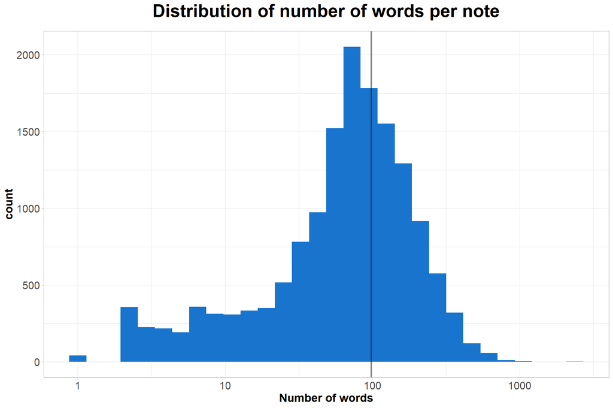

```r
ProtestRaw[notes %like% "\\w",
           .(id, `Number of words` = str_squish(notes) |> str_count(" ")+1)
          ][, word_avg := mean(`Number of words`)] |>
  ggplot(aes(`Number of words`))+
  geom_histogram(bins = 30, fill = "dodgerblue3")+
  geom_vline(aes(xintercept = word_avg))+
  scale_x_log10()+
  labs(title = "Distribution of number of words per note")
```

- **sources** has a paragraph that describes where the is information is coming from. The average number of words for each paragraph is *34 words* which is higher than median so there are some outliers with very long paragraphs.

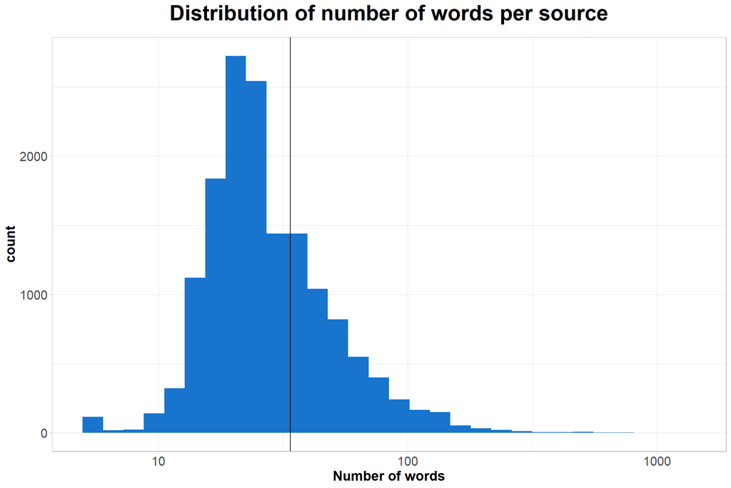

```r
ProtestRaw[sources %like% "\\w",
           .(id, `Number of words` = str_squish(sources) |> str_count(" ")+1)
          ][, word_avg := mean(`Number of words`)] |>
  ggplot(aes(`Number of words`))+
  geom_histogram(bins = 30, fill = "dodgerblue3")+
  geom_vline(aes(xintercept = word_avg))+
  scale_x_log10()+
  labs(title = "Distribution of number of words per source")
```

## 2.2 Missing data distribution

It is important to know that the data has *17,145 rows*, but not all rows represent a protest, *1,906 rows* of the data represent years where the wasn’t any protest in a particular country. Let’s see how is the missing value distribution in each case.

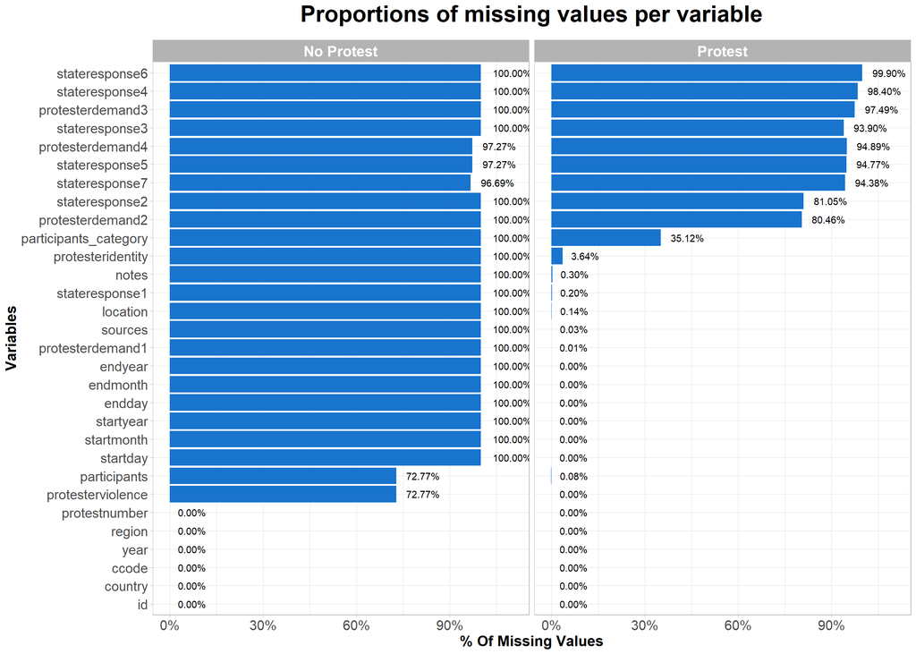

```r
ProtestRaw[, lapply(.SD, function(x) x |> is.na() |> mean()),
    by = .(protest = fifelse(protest>0,"Protest","No Protest"))
  ][, melt(.SD, id.vars = "protest",
           variable.name = "Variables",
           value.name = "# Missing")
  ][, Variables := fct_reorder(Variables, `# Missing`, sum)] |>
  ggplot(aes(`# Missing`, `Variables`))+
  geom_blank(aes(x = `# Missing` *1.1))+
  geom_col(fill = "dodgerblue3")+
  geom_text(aes(label = percent(`# Missing`, accuracy = 0.01)),
            hjust = -0.3)+
  scale_x_continuous(labels = percent_format(accuracy = 1))+
  facet_wrap(~protest)+
  labs(title = "Proportions of missing values per variable",
       x = "% Of Missing Values")
```

As we can check the rows that doesn’t represent a protest are very empty. We will remove them as they won’t be useful to answer the question.

# 3 Data cleaning process

After checking the data feature by feature we got a better sense of the data and a better vision of the problems that need to be solved before getting insight from the data.

## 3.1 Initial cleaning

In this section we will apply simplest cleaning steps at once.

```r
ProtestSimpleClean <-

  # Fixing wrong ccodes
  CountryCodeConsolidated[, .(country = country.name.en, year, p4n)
  ][, unique(.SD)
  ][ProtestRaw, on = c("country","year")
  ][ccode != p4n, ccode := p4n
  ][, !c("p4n")

  # Taking out rows that aren't related to a protest
  ][protest == 1, !c("protest")

  # Transforming start and end dates to a date format
  ][, `:=`(start_date =
             paste(startyear,startmonth,startday,sep = "-") |> ymd(),
           end_date =
             paste(endyear,endmonth,endday,sep = "-") |> ymd())
  ][order(start_date),
    .SD, .SDcols = !patterns("\\w+year$|\\w+month$|\\w+day$")

  # Correcting the protestnumber of each year and country
  ][, protestnumber := 1:.N,
    by = c("country","year")

  # Setting Country and Location Case
  ][,`:=`(location = keep_lower_letters(location) |>
                     str_replace_all("kiev","kyiv") |>
                     str_replace_all("chittagong","chattogram"),
          country = keep_lower_letters(country)) ]
```

## 3.2 Extracting participants_category from participants column

As the `participants` column contains approximations related to number of people who took place during each protests makes more same to complete the missing `participants_category` based on those approximations by using the next code.

```r
ProtestCategoryClean <-

  # Let's work only with protests that are missing participants_category
  ProtestSimpleClean[is.na(participants_category)

  # Applying general cleaning to participants
  ][,participants := participants |>
                      tolower() |>
                      gsub(pattern = ",", replacement = "") |>
                      gsub(pattern = "\\s+", replacement = " ") |>
                      trimws()

  # Getting the average of participants intervals
  ][, c("min","max") := tstrsplit(participants,"-| to ", fixed = FALSE)
  ][participants %like% "between \\d+ and \\d+",
    `:=`(min = str_match(participants, "between (\\d+) and \\d+")[,2],
         max = str_match(participants, "between \\d+ and (\\d+)")[,2])
  ][, c("min","max") := lapply(.(min, max),
                               \(x) str_extract(x, "\\d+") |> as.double())
  ][, `:=`(participants_clean = (min+max)/2,
           min = NULL,
           max = NULL)

  # Getting number of protesters by using regular expressions
  ][participants %like% "^\\d+$" & is.na(participants_clean),
    participants_clean :=
      as.double(participants)
  ][participants %like% "^\\d+\\+$" & is.na(participants_clean),
    participants_clean :=
      str_remove_all(participants,"\\+") |>
      as.double()
  ][participants %like% "^\\d+s" & is.na(participants_clean),
    participants_clean :=
      str_match(participants,"^(\\d+)s")[,2] |>
      as.double()
  ][participants %like% "^[><]\\d+" & is.na(participants_clean),
    participants_clean :=
      str_match(participants,"^[><](\\d+)")[,2] |>
      as.double()

  # Getting number of protesters by reading the notes variable
  ][id == 922006004,
    participants_clean := 50
  ][id == 6602002005,
    participants_clean := 2000

  # Creating a new participants_category variable
  ][, `:=`(participants_category =
             fcase( between(participants_clean, 1, 99), "1-99",
                    between(participants_clean, 100, 999), "100-999",
                    between(participants_clean, 1000, 1999), "1000-1999",
                    between(participants_clean, 2000, 4999), "2000-4999",
                    between(participants_clean, 5000, 10000), "5000-10000",
                    participants_clean > 10000, ">10000"),
           participants_clean = NULL)

  # Adding protests that aren't missing participants_category
  ][, rbind(.SD,
            ProtestSimpleClean[!is.na(participants_category)])

  # Making participants_category a factor variable
  # to make easier to plot the data later
  ][participants_category == "50-99",
    participants_category := "1-99"
  ][, `:=`(participants_category = factor(participants_category,
                                          levels = c("1-99",
                                                     "100-999",
                                                     "1000-1999",
                                                     "2000-4999",
                                                     "5000-10000",
                                                     ">10000")),
           participants = NULL)]



ProtestCategoryClean[, .N, participants_category
  ][order(-N)] |>
  style_table()
```

| participants_category | N |
| --- | --- |
| 100-999 | 4,917 |
| 1-99 | 3,303 |
| >10000 | 2,121 |
| 2000-4999 | 2,019 |
| 1000-1999 | 1,608 |
| 5000-10000 | 1,260 |
|  | 11 |

## 3.3 Reshaping protesterdemand and stateresponse

Now we reorganize the `protesterdemand` and `stateresponse` to have a single column for each category having 1 if the each category is related to the protest and 0 otherwise.

```r
ProtestReshaped <-

  # Melting protesterdemand and stateresponse just keeping protest id
  ProtestCategoryClean[, melt(.SD, id.vars = "id",
                              measure.vars =
                                str_subset(names(.SD),
                                           "^(protesterdemand|stateresponse)"),
                              value.name = "actions",
                              variable.factor = FALSE)
  ][actions %like% "\\w"
  ][,`:=`(variable = fifelse(variable %like% "^protesterdemand",
                             "dem","res"),
          actions = fifelse(actions == "accomodation",
                            "accommodation",actions),
          action_occur = TRUE)
  ][, unique(.SD)
  ][, dcast(.SD, id ~ variable + actions,
            value.var = "action_occur", fill = FALSE)


  # Adding the other variables to have back the data complete
  ][, merge(.SD,
            ProtestCategoryClean,
            by = "id", all = TRUE)
  ][, .SD,
    .SDcols = !patterns("^(protesterdemand|stateresponse)")
  ][,{
    ColsToFill <- str_subset(names(.SD),"^(dem|res)")
    copy(.SD)[is.na(res_shootings), (ColsToFill) := FALSE]
  }][, protesterviolence := protesterviolence == 1]
```

After applying those changes we can see that currently all the columns have less than 5% of missing values.

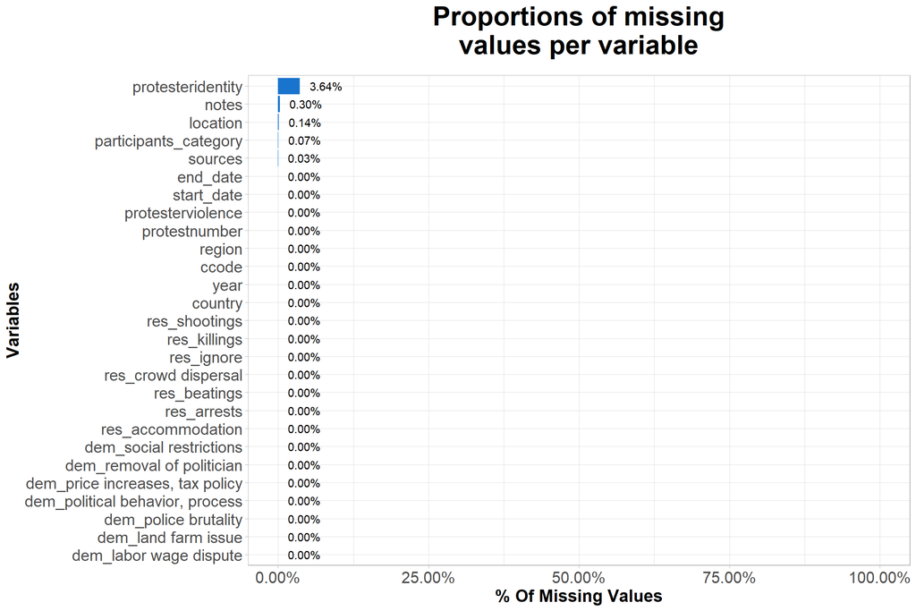

```r
ProtestReshaped[, lapply(.SD, function(x) mean(is.na(x)))
  ][, id := 1
  ][, melt(.SD, id.vars = "id",
           variable.name = "Variables",
           value.name = "# Missing")
  ][, `:=`(Variables = fct_reorder(Variables, `# Missing`, sum))] |>
  ggplot(aes(`# Missing`, `Variables`))+
  geom_blank(aes(x = `# Missing` *1.15))+
  geom_col(fill = "dodgerblue3")+
  geom_text(aes(label = percent(`# Missing`, accuracy = 0.01)), hjust = -0.3)+
  scale_x_continuous(labels = percent_format(accuracy = 0.01))+
  expand_limits(x = 1)+
  labs(title = "Proportions of missing\nvalues per variable",
       x = "% Of Missing Values")
```

## 3.4 Joining policatical situation

As we already confirmed that the data is related to Center for Systemic Peace data adding the variables to the main data can be done in one line of code.

```r
ProtestPolitical <-
  Polity5[ProtestReshaped, on = c("ccode","year")]
```

## 3.5 Extracting location data

As we know in the column `location` there is information about the place where each protests took place. I would be really interesting to extract from that field the following information:

1. Does it mention if it was a national protest?
2. How many cities mention each protest?
3. Did the protest took place in the capital?

To achieve that we need to make the process in 3 steps.

- In the first step we need check in the `location` field mention if the protest took place nationality and identify the cities that have a perfect math with the `WorldCities` data frame.

```r
NationalRegex <-
  "nationwide|(^| )national( level| including| in scope|.+cities|$|[:;,\\.])|across (.*country|"

CustomStopWords <-
  c(stop_words$word, tm::stopwords("spanish"), "region",
    "province", "district", "valley", "including","cities",
    "shire", "downtown", "national", "parliament")

ProtestExactCityMatch <-
  WorldCities[, .(city_regex = str_c(city_ascii,collapse = "|")),
              by = "country"
  ][ProtestPolitical, on = "country"
  ][, `:=`(exact_cities_found = .(str_extract_all(location, city_regex) |>
                                    unlist() |>
                                    unique()),
           is_national = location %like% str_c(NationalRegex, country,")"),
           location_no_found = str_remove_all(location, city_regex) |>
                               str_remove_all(str_c(NationalRegex, country,")")) |>
                               str_squish()),
    by = "id"
  ][,`:=`(num_cities = sapply(exact_cities_found, length),
          city_regex = NULL)
  ][!location_no_found %like% "\\w" |
      location_no_found %chin% CustomStopWords,
    location_no_found := NA_character_]
```

After extracting all matching cities and checking if the location field identified each protest as a national one we saved the remaining words in the variable `location_no_found` for further analysis.

- Assuming the in many cases of `location_no_found` the remaining words just make reference to one city we can compare all the cities of each country and take the city that minimize the LCS (longest common sub-string distance) measure from the `stringdist` package.

```r
StringApproxCols <-
  c("id", "country", "location", "location_no_found", "num_cities")

OneWorldCityApprox <-
  ProtestExactCityMatch[!is.na(location_no_found), ..StringApproxCols] |>
  find_string_approximation(DT2 = WorldCities[,.(country, city_ascii)],
                            id.var = "id",
                            merge.by = "country",
                            match.vars = c("location_no_found","city_ascii")) |>
  setnames("location_no_found","city_word")
```

At the end, we could find 897 protest cities. but that with that we can find cities if the field describes more than one city. To check that let’s see the number of words distribution.

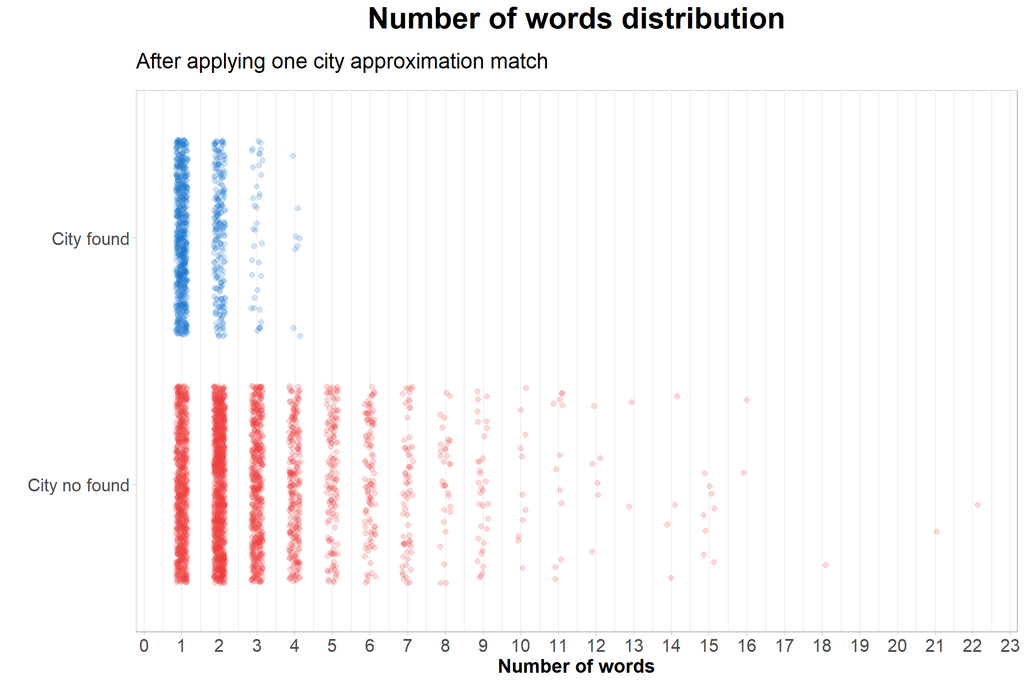

```r
plot_word_found_distribution(ProtestExactCityMatch,
                             word.count.var = "location_no_found",
                             prostest.id.found = OneWorldCityApprox$id,
                             success.label = "City found",
                             no.found.label = "City no found",
                             label.colors = c("City found" = "dodgerblue3",
                                              "City no found" = "brown2"),
                             subtitle = "After applying one city approximation match")
```

As we can see most of the cities found only have one of two words and only some few one have 3 or 4 words. It is all also important to check that rows with one word didn’t find any city related so we can take those cases out as we won’t any extra city related those cases.

```r
ManyWorldCityApprox <-
  lapply(1:4, function(n_gram){
  ProtestExactCityMatch[!is.na(location_no_found) &
                          str_count(location_no_found," ") >= 1 &
                          !id %in% OneWorldCityApprox$id,
                        unnest_tokens(.SD, city_word,location_no_found,
                                      token = "ngrams", n = n_gram),
                        .SDcols = StringApproxCols
  ][! city_word %chin% CustomStopWords,
    find_string_approximation(.SD,
                              DT2 = WorldCities[,.(country, city_ascii)],
                              id.var = "id",
                              merge.by = "country",
                              match.vars = c("city_word","city_ascii"))
  ][, n_gram := n_gram]}) |>
  rbindlist()
```

In next chart we can see how we could find cities in very long text with more than 20 words by applying string distance approximation.

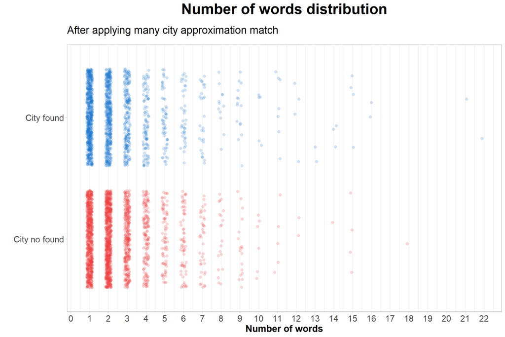

```r
plot_word_found_distribution(ProtestExactCityMatch,
                             word.count.var = "location_no_found",
                             prostest.id.found = c(OneWorldCityApprox$id,
                                                   ManyWorldCityApprox$id),
                             success.label = "City found",
                             no.found.label = "City no found",
                             label.colors = c("City found" = "dodgerblue3",
                                              "City no found" = "brown2"),
                             subtitle = "After applying many city approximation match")
```

Now it’s time to add the cities found to the main data.

```r
ProtestLocationExtracted <-
  list(OneWorldCityApprox[, c("id","country","city_ascii")],
       ManyWorldCityApprox[, c("id","country","city_ascii")],
       ProtestExactCityMatch[, .(city_ascii = exact_cities_found[[1]]),
                             by = c("id","country")]) |>
  rbindlist() |>
  unique() |>
  merge(WorldCities,
        by = c("country","city_ascii"), all.x = TRUE) |>
  (\(DT) DT[, .(cities_found = .(city_ascii),
                num_cities = .N,
                in_capital = sum(capital == "primary",na.rm = TRUE) > 0,
                total_population = sum(population, na.rm = TRUE)),
            by = "id"
         ][ProtestExactCityMatch[,!c("exact_cities_found",
                                     "num_cities",
                                     "location_no_found",
                                     "location")],
           on = "id"
         ][is.na(num_cities),
           `:=`(num_cities = 0,
                in_capital = FALSE)])()

glimpse(ProtestLocationExtracted)
```

```
Rows: 15,239
Columns: 37
$ id                                <dbl> 201990001, 201990002, 201990003, 201…
$ cities_found                      <list> <NULL>, <"montreal", "quebec city">…
$ num_cities                        <int> 0, 2, 2, 2, 2, 2, 0, 0, 1, 1, 0, 1, …
$ in_capital                        <lgl> FALSE, FALSE, FALSE, FALSE, FALSE, F…
$ total_population                  <dbl> NA, 4224698, 4224698, 4224698, 42246…
$ country                           <chr> "canada", "canada", "canada", "canad…
$ ccode                             <int> 20, 20, 20, 20, 20, 20, 20, 20, 20, …
$ year                              <int> 1990, 1990, 1990, 1990, 1990, 1990, …
$ democ                             <dbl> 10, 10, 10, 10, 10, 10, 10, 10, 10, …
$ autoc                             <dbl> 0, 0, 0, 0, 0, 0, 0, 0, 0, 0, 0, 0, …
$ polity                            <dbl> 10, 10, 10, 10, 10, 10, 10, 10, 10, …
$ durable                           <int> 102, 102, 102, 102, 102, 102, 103, 1…
$ government_status                 <chr> "Active", "Active", "Active", "Activ…
```

[output cut: 24 more lines]

# 4 Data exploration

After applying many transformations to the data we are ready to explore it. The new data it is tidy format and we will easy to manipulate across the exploration process.

## 4.1 Exploring numeric correlations

A we can see the data have some numeric and logical variables that can be converted to numeric. It would be really interesting if we can confirm which variables go in same or opposite directions. To find out that we can use the `correlation` function from the **correlation** package which also give us confident intervals to confirm that the correlation are statistician significance.

The first step it’s to take out variables that don’t bring big insights and case of finding any relation, then we select logical and numeric variables and calculate correlations for all numeric and logical variables.

```r
CorSummary <-
  ProtestLocationExtracted[, !c("id","ccode","democ","autoc", "durable")
  ][, participants_category := as.integer(participants_category)
  ][, lapply(.SD, \(x) x * 1),
    .SDcols = \(x) is.logical(x) | is.numeric(x)] |>
  correlation() |>
  as.data.frame() |>
  as.data.table()

CorSummary[1:6,
           lapply(.SD, \(x) if(is.numeric(x)){round(x,2)}else{x}),
           .SDcols = !patterns("^(t|df_error)$")] |>
  style_table()
```

| Parameter1 | Parameter2 | r | CI | CI_low | CI_high | p | Method | n_Obs |
| --- | --- | --- | --- | --- | --- | --- | --- | --- |
| num_cities | in_capital | 0.26 | 0.95 | 0.24 | 0.27 | 0.00 | Pearson correlation | 15,239 |
| num_cities | total_population | 0.15 | 0.95 | 0.13 | 0.17 | 0.00 | Pearson correlation | 13,029 |
| num_cities | year | 0.04 | 0.95 | 0.02 | 0.05 | 0.00 | Pearson correlation | 15,239 |
| num_cities | polity | 0.00 | 0.95 | -0.02 | 0.01 | 1.00 | Pearson correlation | 13,804 |
| num_cities | dem_labor wage dispute | -0.03 | 0.95 | -0.05 | -0.02 | 0.00 | Pearson correlation | 15,239 |
| num_cities | dem_land farm issue | -0.02 | 0.95 | -0.04 | -0.01 | 0.22 | Pearson correlation | 15,239 |

As we have many significant correlations, let’s center our attention in correlations equals or greater than `0.10`.

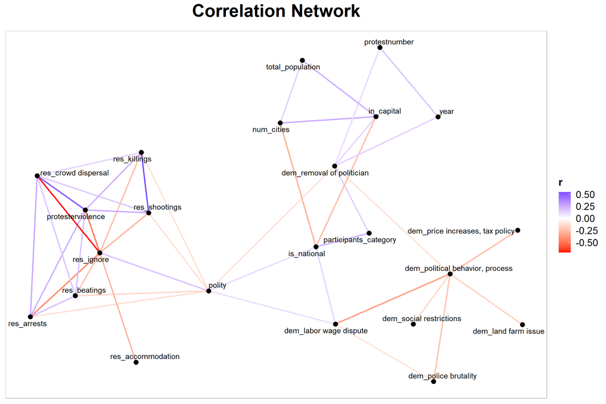

```r
set.seed(110)
CorSummary[p < 0.05 & abs(r) >= 0.10] |>
  graph_from_data_frame(directed = FALSE) |>
  ggraph(layout = "with_dh")+
  geom_edge_link(aes(edge_color = r),
                 edge_width = 1)+
  geom_node_point(size = 3)+
  geom_node_text(aes(label = name), repel = TRUE)+
  scale_edge_color_gradient2(low = "red", high = "blue")+
  labs(title = "Correlation Network")
```

By checking the last graph, we can see some interesting relations:

1. **Protesters violence** during manifestations result in shootings, killings, beatings and arrests in countries with low polity (democracy).
2. Petitions to **remove a politician** are massive events (participants_category) with many repetitions per year (protestnumber) that take place in the capital of countries with low polity.
3. **Labor wage disputes** have national impact in countries with high polity.

Now we know that some relations are present in the data let’s explore each of then.

### 4.1.1 Do state responses change depending if the state is a democracy or an autocracy?

To answer that question we need to define what it is the minimum **polity value** to distinct between a democracy and a autocracy.

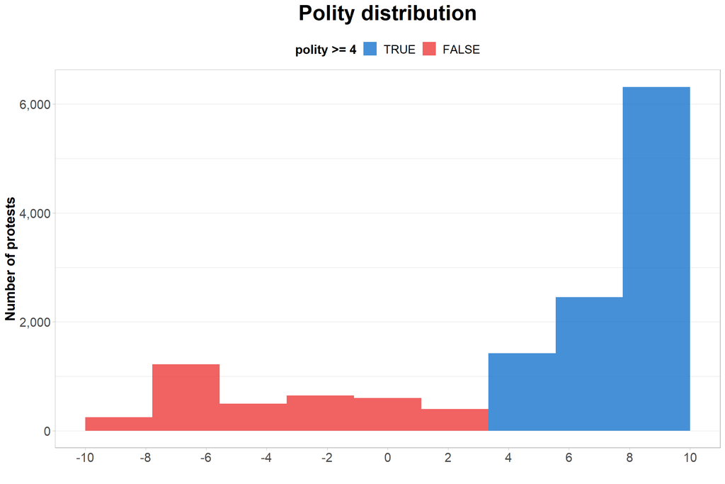

```r
PolityChangeValue <- quantile(ProtestLocationExtracted$polity,
                              probs = 0.3, na.rm = TRUE)

ProtestLocationExtracted[!is.na(polity)] |>
  ggplot(aes(polity, fill = polity >= PolityChangeValue)) +
  geom_histogram(bins = 10, alpha = 0.8)+
  scale_x_continuous(breaks = breaks_width(2))+
  scale_y_continuous(labels = comma_format()) +
  scale_fill_manual(values = c("TRUE" = "dodgerblue3",
                               "FALSE" = "brown2"))+
  labs(title = "Polity distribution",
       y = "Number of protests", x = "",
       fill = paste0("polity >= ", PolityChangeValue))+
  theme(panel.grid.major.x = element_blank(),
        panel.grid.minor.x = element_blank(),
        legend.position = "top")
```

By checking the distribution, it seems good taking 4 as the minimum polity level to say that the country it’s a democracy as 30% of protest take place in countries with lower values.

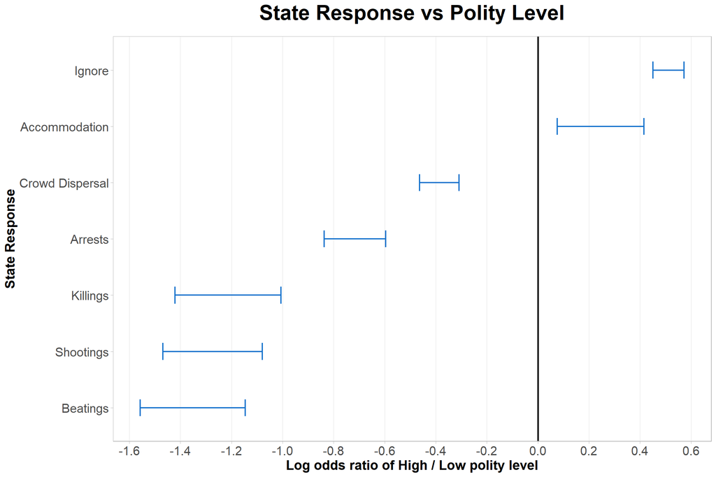

```r
set.seed(2022)

ResposeVsGovermentType <-
  ProtestLocationExtracted[!is.na(polity),
                           melt(.SD,
                                id.vars = c("id","polity"),
                                value.name = "Happen",
                                variable.name = "Response",
                                variable.factor = FALSE,
                                na.rm = TRUE),
                           .SDcols = patterns("^(id|polity)$|^res")
  ][, `:=`(goverment_type = fifelse(polity < PolityChangeValue, "Low Democracy", "High Democracy"),
           polity = NULL,
           Response = sub("^res_","",Response) |> str_to_title())
  ][, specify(.SD,
              formula = Happen ~ goverment_type,
              success = "TRUE") |>
      generate(reps = 1000, type = "bootstrap") |>
      calculate(stat = "ratio of props",
                order = c("High Democracy", "Low Democracy")) |>
      as.data.table() |>
      DT(j = stat := log2(stat)) |>
      get_ci(type = "percentile"),
    by = "Response"
  ][, Response := fct_reorder(Response, upper_ci, sum)]


ggplot(ResposeVsGovermentType, aes(y = Response))+
  geom_errorbarh(aes(xmin = lower_ci, xmax = upper_ci),
                 height = 0.3, size = 0.8,
                 color = "dodgerblue3")+
  geom_vline(aes(xintercept = 0), size = 1)+

  scale_x_continuous(breaks = breaks_width(0.2))+
  scale_color_manual(values = c("FALSE" = "dodgerblue3",
                                "TRUE" = "brown2"))+
  labs(title = "State Response vs Polity Level",
       y = "State Response",
       x = "Log odds ratio of High / Low polity level")+
  theme(panel.grid.major.y = element_blank(),
        panel.grid.minor.y = element_blank(),
        panel.grid.minor.x = element_blank(),
        legend.position = "top")
```

After calculating confidence intervals using the bootstrap technique we can conclude that the proportion of protests that result in state **ignore** and **accommodation** is significant higher in democratic countries than autocratic ones.

On the other hand, the proportion of protests that result in state **crowd dispersal**, **arrest**, **killing**, **shooting** and **beating** is significant higher in autocratic countries than democratic ones.

But, can this results change by taking in consideration if the protesters present violent during the protest?

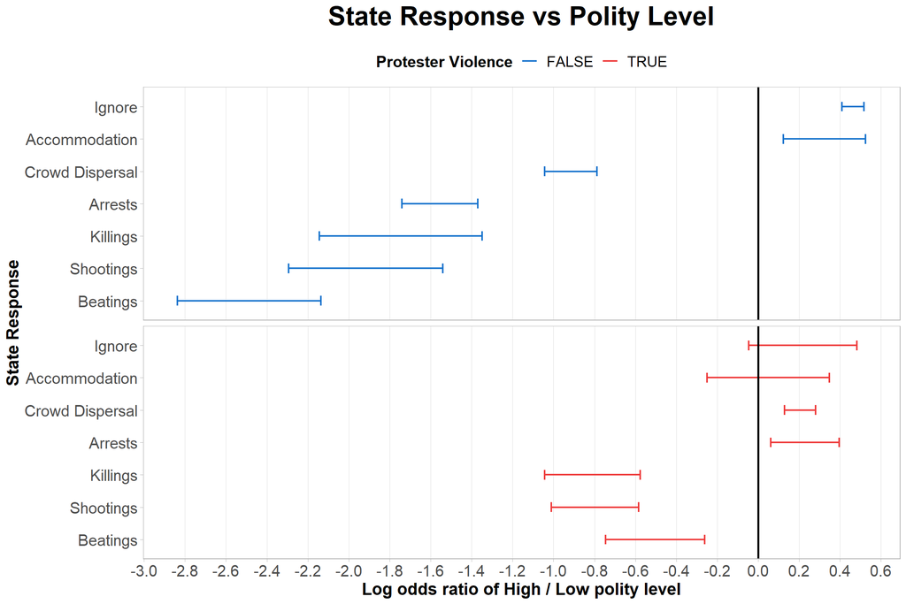

```r
set.seed(2022)

ResposeVsGovermentTypeViolence <-
  ProtestLocationExtracted[!is.na(polity),
                           melt(.SD,
                                id.vars = c("id","polity","protesterviolence"),
                                value.name = "Happen",
                                variable.name = "Response",
                                variable.factor = FALSE,
                                na.rm = TRUE),
                           .SDcols = patterns("^(id|polity|protesterviolence)$|^res")
  ][, `:=`(goverment_type = fifelse(polity < PolityChangeValue, "Low Democracy", "High Democracy"),
           polity = NULL,
           Response = sub("^res_","",Response) |> str_to_title())
  ][, specify(.SD,
              formula = Happen ~ goverment_type,
              success = "TRUE") |>
      generate(reps = 1000, type = "bootstrap") |>
      calculate(stat = "ratio of props",
                order = c("High Democracy", "Low Democracy")) |>
      as.data.table() |>
      DT(j = stat := log2(stat)) |>
      get_ci(type = "percentile"),
    by = c("Response", "protesterviolence")
  ][, Response := fct_reorder(Response, upper_ci, sum)]


ggplot(ResposeVsGovermentTypeViolence, aes(y = Response))+
  geom_errorbarh(aes(xmin = lower_ci, xmax = upper_ci,
                     color = protesterviolence),
                 height = 0.3, size = 0.8)+
  geom_vline(aes(xintercept = 0), size = 1)+
  facet_wrap(~protesterviolence, ncol = 1)+
  scale_x_continuous(breaks = breaks_width(0.2))+
  scale_color_manual(values = c("FALSE" = "dodgerblue3",
                                "TRUE" = "brown2"))+
  labs(title = "State Response vs Polity Level",
       y = "State Response",
       x = "Log odds ratio of High / Low polity level",
       color = "Protester Violence")+
  theme(panel.grid.major.y = element_blank(),
        panel.grid.minor.y = element_blank(),
        panel.grid.minor.x = element_blank(),
        strip.background = element_blank(),
        strip.text = element_blank(),
        legend.position = "top")
```

When protesters don’t present violence the conclusions are the same, but when they present violence during protests state **ignore** and **accommodation** it’s independent to the government type. We also can see a **Simpson’s Paradox** in **crowd dispersal** and **arrest** as democratic countries has a significant higher proportion of protests with these response. To solve this problem we will need to use statistical modeling before getting our final conclusions.

### 4.1.2 How many people attent to protests according to each demand?

(This chart would be more easier if participants_category were numeric)

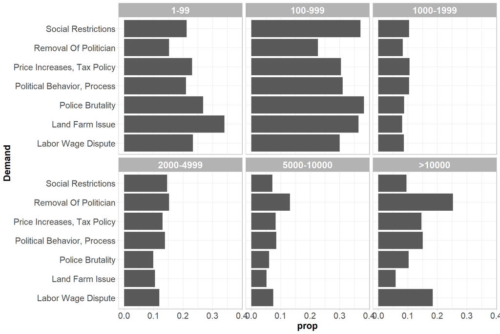

```r
ProtestLocationExtracted[!is.na(participants_category),
                         melt(.SD,
                                id.vars = c("id","participants_category"),
                                value.name = "Happen",
                                variable.name = "Demand",
                                variable.factor = FALSE,
                                na.rm = TRUE),
                         .SDcols = patterns("^(id|participants_category)$|^dem_")
][Happen == TRUE,
  .(N = uniqueN(id)),
  by = .(Demand = sub("^dem_","",Demand) |> str_to_title(),
         participants_category)
][, prop := N / sum(N),
  by = "Demand"] |>
  ggplot(aes(prop, Demand))+
  geom_col()+
  facet_wrap(~participants_category)
```

- Adding text to identify each side meaning

Arel-Bundock, Vincent, Nils Enevoldsen, and CJ Yetman, (2018). countrycode: An R package to convert country names and country codes. Journal of Open Source Software, 3(28), 848, https://doi.org/10.21105/joss.00848

https://www.systemicpeace.org/inscrdata.html (Center for Systemic Peace)

https://simplemaps.com/data/world-cities